# Bias in stratum-specific abundance estimates

Brief distance sampling simulation where detection functions differ between strata. When stratum-specific abundance estimates are produced using a pooled detection function, bias arises. The magnitude of the bias depends upon the magnitude of the difference in the detection functions.

Eric Rexstad https://distancesampling.org (Centre for Research into Ecological and Environmental Modelling)https://www.creem.st-andrews.ac.uk/  
2022-02-27

# Introduction

We tell participants in the introductory distance sampling workshop of the perils of estimating stratum-specific densities when using a pooled detection function (Buckland et al., 2015, Sect. 2.3.1). Therefore, if the purpose of the study is to produce stratum-specific density estimates, sufficient effort must be allocated per stratum to support stratum-specific detection functions. It might be the case that multiple strata share the same detection function, but reliance upon luck for that to occur is not the basis for sound inference. Sufficient detections should be made in each stratum to assess whether strata share a common detection function.

This simulation study evaluates the magnitude of bias in stratum-specific density estimates when strata differ in the scale parameter of their detection functions.

```r
library(dsims)
library(leaflet)
library(knitr)
library(sf)
library(here)
```

# Study area

The only interesting feature of the study area used in this simulation is that it possesses two strata. We could have employed more strata, but demonstration of the phenomenon is sufficient with only two strata.

```r
myshapefilelocation <- here("shapefiles", "StrataPrj.shp")
northsea <- make.region(region.name = "minkes",
                      shape = myshapefilelocation,
                      strata.name = c("South", "North"),
                      units = "km")
```

## North Sea study area

```r
m <- leaflet() %>% addProviderTiles(providers$Esri.OceanBasemap)
m <- m %>%
  setView(1.4, 55.5, zoom=5)
minkes <- read_sf(myshapefilelocation)
study.area.trans <- st_transform(minkes, '+proj=longlat +datum=WGS84')
m <- addPolygons(m, data=study.area.trans$geometry, weight=2)
m
```

[interactive chart not shown]

# Population specification

Population is evenly distributed (density surface is horizontal) and the population size is apportioned to the strata according to the stratum size. This should result in both strata having the same density.

```r
areas <- northsea@area
prop.south <- areas[1]/sum(areas)
prop.north <- areas[2]/sum(areas)
total.abundance <- 3000
abund.south <- round(total.abundance * prop.south)
abund.north <- round(total.abundance * prop.north)
constant <- make.density(region = northsea, x.space = 10, constant = 1)
minkepop <- make.population.description(region = northsea,
                                           density = constant,
                                           N = c(abund.south, abund.north))
```

# Survey design

Specifying a single value for the number of samples will distribute the transects among strata proportional to the stratum sizes. Emphasis of this simulation study is *not* upon the properties of the survey design, therefore a simple systematic parallel line transect survey is created. Note however, there is large number of replicate transects in each stratum; a well-designed study. Any bias in the estimated densities cannot be attributed to poor design.

```r
coverage.grid <- make.coverage(northsea, n.grid.points = 100)
equal.cover <- make.design(region = northsea,
                           transect.type = "line",
                           design = "systematic",
                           samplers=40,
                           design.angle = c(50, 40),
                           truncation = 0.8,
                           coverage.grid = coverage.grid)
```

## Properties of the design

To demonstrate the estimated number of transects in each stratum, the `run.coverage` function is used to show the number of replicates in each stratum is allocated roughly according to stratum size.

```r
design.properties <- run.coverage(equal.cover, reps = 10, quiet=TRUE)
mine <- data.frame(Num.transects=design.properties@design.statistics$sampler.count[3,],
                   Proportion.covered=design.properties@design.statistics$p.cov.area[3,])
kable(mine)
```

|  | Num.transects | Proportion.covered |
| --- | --- | --- |
| South | 17 | 8.10 |
| North | 23 | 8.11 |
| Total | 40 | 8.12 |

# What analysis to conduct

For purposes of this investigation, we look only at the same key function under which the data were simulated (the half normal) with no covariates. In effect we are using the “wrong model” to make inference, except in the circumstance when $\Delta = 1$.

A second analysis, `strat.specific.or.not` is constructed to assess model selection performance: the “wrong” model is paired with the “correct” model that assumes stratum-specific detectability. This contrast will measure the ability of AIC to choose the correct model as the difference between stratum-specific scale parameters ($\Delta$) changes.

```r
pooled.hn <- make.ds.analysis(dfmodel = list(~1),
                                key = "hn",
                                criteria = "AIC",
                                truncation = 0.8)
strat.specific.or.not <- make.ds.analysis(dfmodel = list(~1, ~Region.Label),
                                key = "hn",
                                criteria = "AIC",
                                truncation = 0.8)
```

# Heart of the simulation

## Loop over $\Delta$ difference in $\sigma$ between strata

```r
delta.multiplier <- c(seq(from=0.5, to=1.1, by=0.1),
#                      seq(from=0.85, to=1.15, by=0.1),
                      seq(from=1.2, to=2.4, by=0.2))
sigma.south <- 0.3
north.sigma <- sigma.south*delta.multiplier
```

Scale parameter ($\sigma$) for the southern stratum remains fixed at 0.3, but in the northern stratum, the scale parameter is a multiple of the southern stratum $\sigma$, ranging from a low of 0.15 to a maximum of 0.72.

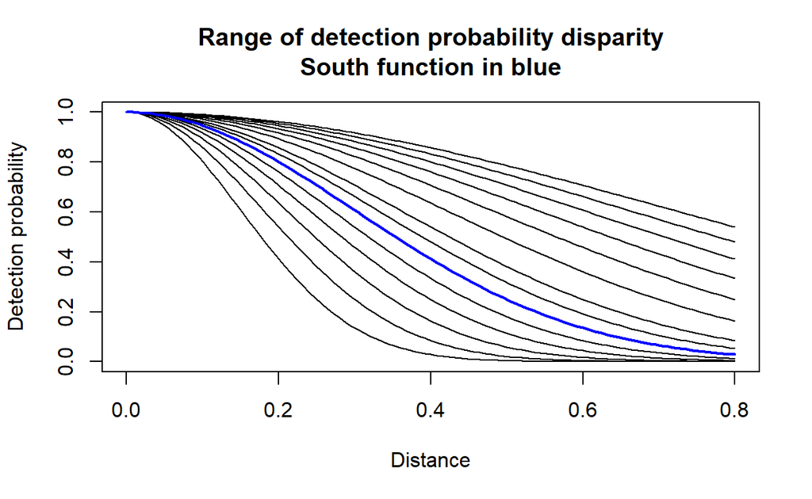

```r
hn <- function(sigma, x) {return(exp(-x^2/(2*sigma^2)))}
for (i in seq_along(north.sigma)) {
  curve(hn(north.sigma[i],x),from=0,to=0.8,add=i!=1,
        xlab="Distance", ylab="Detection probability",
        main="Range of detection probability disparity\nSouth function in blue")
}
curve(hn(sigma.south,x),from=0,to=0.8, lwd=2, col='blue', add=TRUE)
```

```r
equalcover <- list()
whichmodel <- list()
num.sims <- 1000
for (i in seq_along(delta.multiplier)) {
  sigma.strata <- c(sigma.south, sigma.south*delta.multiplier[i])
  detect <- make.detectability(key.function = "hn",
                               scale.param = sigma.strata,
                               truncation = 0.8)
  equalcover.sim <- make.simulation(reps = num.sims,
                                    design = equal.cover,
                                    population.description = minkepop,
                                    detectability = detect,
                                    ds.analysis = pooled.hn)
  whichmodel.sim <- make.simulation(reps = num.sims,
                                    design = equal.cover,
                                    population.description = minkepop,
                                    detectability = detect,
                                    ds.analysis = strat.specific.or.not)
  equalcover[[i]] <- run.simulation(equalcover.sim, run.parallel = TRUE, max.cores=11)
  whichmodel[[i]] <- run.simulation(whichmodel.sim, run.parallel = TRUE, max.cores=11)
}
```

# Simulation findings

Tabular results of simulations iterating over the range of $\Delta$ values for the scale parameters of the two strata. As $\Delta$ approaches 1, the two detection functions converge, hence using the pooled detection function is appropriate. When $\Delta>1$ bias again increases, however because for values of $\Delta>>1$, the detection function for the North stratum becomes nearly horizontal. The number of detections in the North stratum is becoming asymptotic. There is little margin for bias to arise in the North density estimate; bulk of bias arises from estimates in the South stratum.

Table 1: Results using pooled detection function

|  | Bias.N | Bias.S | Bias.Tot | CICover.N | CICover.S | CICover.Tot | Detects.N | Detects.S | Detects.Tot | Prop.strat.model |
| --- | --- | --- | --- | --- | --- | --- | --- | --- | --- | --- |
| 0.5 | -35.1 | 27.5 | -12.9 | 0.33 | 0.72 | 0.80 | 37 | 40 | 78 | 1.00 |
| 0.6 | -23.6 | 24.0 | -6.7 | 0.62 | 0.76 | 0.90 | 45 | 40 | 85 | 0.97 |
| 0.7 | -14.5 | 19.6 | -2.4 | 0.83 | 0.82 | 0.94 | 52 | 40 | 93 | 0.79 |
| 0.8 | -8.5 | 14.1 | -0.5 | 0.91 | 0.89 | 0.95 | 59 | 41 | 100 | 0.51 |
| 0.9 | -3.4 | 6.6 | 0.2 | 0.94 | 0.93 | 0.95 | 66 | 40 | 106 | 0.27 |
| 1 | -0.1 | 0.3 | 0.0 | 0.96 | 0.96 | 0.96 | 73 | 40 | 114 | 0.18 |
| 1.1 | 3.0 | -6.2 | -0.3 | 0.95 | 0.92 | 0.94 | 80 | 40 | 120 | 0.22 |
| 1.2 | 5.7 | -10.3 | 0.0 | 0.93 | 0.91 | 0.95 | 87 | 40 | 127 | 0.36 |
| 1.4 | 8.8 | -18.0 | -0.7 | 0.90 | 0.79 | 0.94 | 98 | 40 | 138 | 0.66 |
| 1.6 | 9.4 | -24.9 | -2.7 | 0.88 | 0.61 | 0.94 | 107 | 40 | 147 | 0.85 |
| 1.8 | 11.4 | -27.9 | -2.6 | 0.86 | 0.53 | 0.95 | 114 | 41 | 155 | 0.93 |
| 2 | 12.8 | -30.7 | -2.7 | 0.82 | 0.45 | 0.95 | 121 | 41 | 162 | 0.97 |
| 2.2 | 12.9 | -33.7 | -3.6 | 0.83 | 0.32 | 0.93 | 126 | 40 | 166 | 0.98 |
| 2.4 | 13.8 | -35.6 | -3.7 | 0.80 | 0.26 | 0.93 | 130 | 40 | 170 | 0.99 |

Table 2: Bias in density estimates when using model selected using AIC.

|  | Bias.N | Bias.S | Bias.Tot | CICover.N | CICover.S | CICover.Tot |
| --- | --- | --- | --- | --- | --- | --- |
| 0.5 | 2.3 | 1.3 | 2.0 | 0.96 | 0.95 | 0.95 |
| 0.6 | 2.2 | 0.4 | 1.5 | 0.94 | 0.96 | 0.95 |
| 0.7 | 0.9 | 4.0 | 2.0 | 0.93 | 0.91 | 0.96 |
| 0.8 | -0.3 | 4.5 | 1.4 | 0.93 | 0.93 | 0.95 |
| 0.9 | 0.1 | 3.4 | 1.2 | 0.93 | 0.95 | 0.96 |
| 1 | -0.1 | 0.8 | 0.2 | 0.94 | 0.95 | 0.95 |
| 1.1 | 2.3 | -0.8 | 1.2 | 0.94 | 0.94 | 0.95 |
| 1.2 | 2.5 | -2.0 | 0.9 | 0.94 | 0.90 | 0.95 |
| 1.4 | 1.7 | -1.5 | 0.6 | 0.94 | 0.88 | 0.94 |
| 1.6 | 0.5 | 0.8 | 0.6 | 0.95 | 0.90 | 0.97 |
| 1.8 | 0.8 | 1.2 | 0.9 | 0.94 | 0.93 | 0.96 |
| 2 | 0.2 | 0.9 | 0.4 | 0.96 | 0.94 | 0.95 |
| 2.2 | 0.2 | 2.3 | 1.0 | 0.95 | 0.95 | 0.95 |
| 2.4 | 0.3 | 2.0 | 0.9 | 0.96 | 0.96 | 0.96 |

## Conclusions from this portion of study

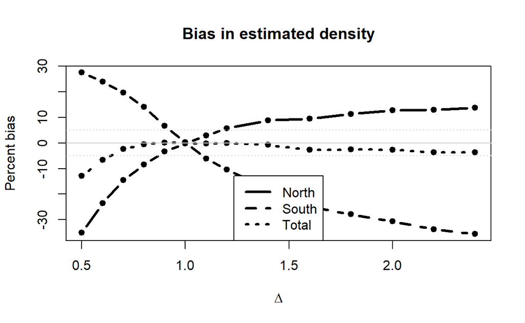

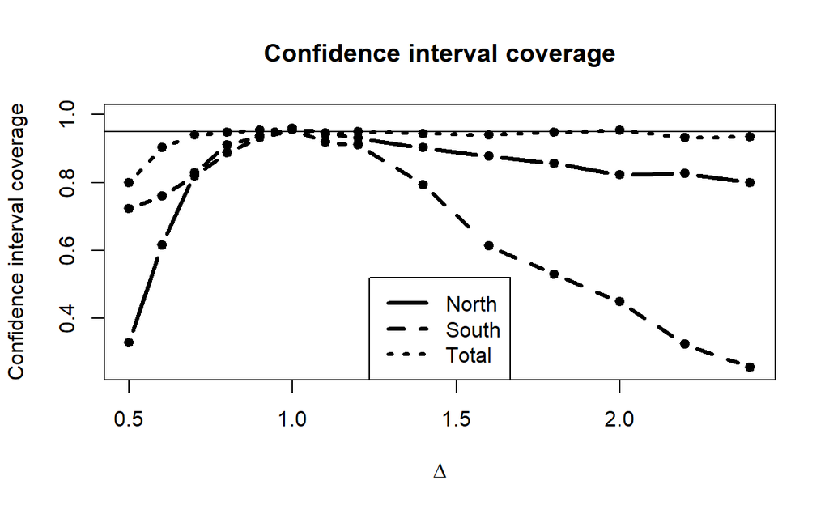

Confidence interval coverage for stratum-specific estimates approaches nominal levels when $\Delta \approx 1$. Coverage for the density estimate in the entire study area is nominal for all values of $\Delta$ with the exception of $\Delta<0.7$.

## Model selection sensitivity

This small simulation demonstrates the peril of making stratum-specific estimates when using a detection function that does not recognise stratum-specific detection function differences. This situation can arise when numbers of stratum-specific detections are too small to support stratum-specific detection functions. This set of simulations was devised such that there was sufficient effort in each stratum to avoid small numbers of detections. Even so, use of the “wrong” (pooled) detection function leads to considerable bias in density estimates.

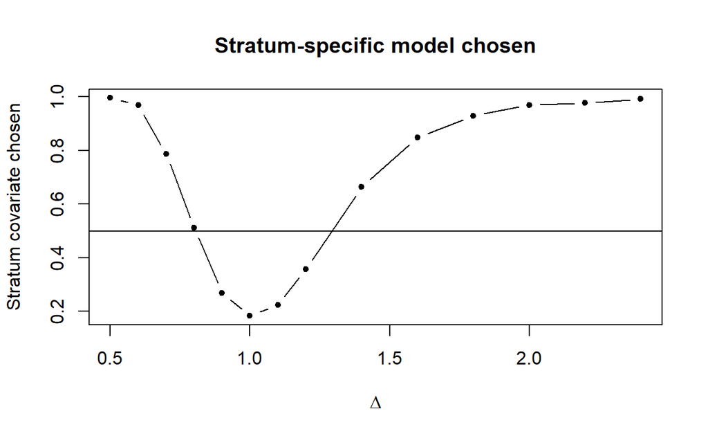

```r
plot(delta.multiplier, modelsel,
     main="Stratum-specific model chosen", type="b", pch=20,
     xlab=expression(Delta), ylab="Stratum covariate chosen")
abline(h=0.50)
```

Buckland, S. T., Rexstad, E. A., Marques, T. A., & Oedekoven, C. S. (2015). *Distance sampling: Methods and applications*. Springer.